# workflow for effective data management

2018-01-26

research data workflow: this is your world (or it will be soon)

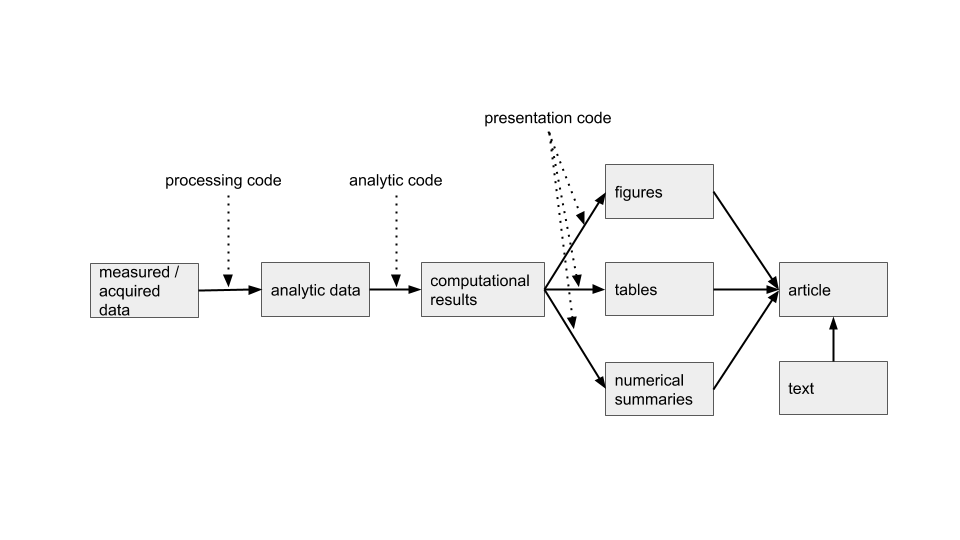

modified from Jenny Bryan’s UBC Stat 545 course (http://stat545.com/) who adapted it from Roger Peng (biostat.jhsph.edu/~rpeng/)

### challenges

- how do you keep that up-to-date?
- what if something changes, what if something needs to be redone - how do you manage that?
- why do the results in table 1 not seem to correspond to the results in figure 1?
- why were those particular samples omitted?
- where did I get these data?
- how did I make that figure?

**basically, if the thought of redoing your analyses is terrifying then you are doing it wrong (paraphrasing Jenny Bryan)**

research data workflow: this is your world (or it will be soon)

now add to that publishing your data and code

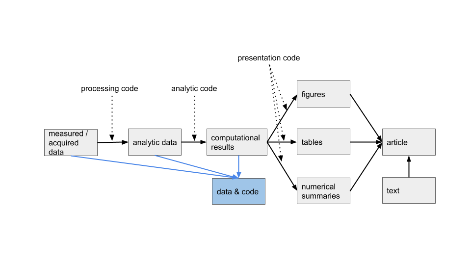

modified from Jenny Bryan’s UBC Stat 545 course (http://stat545.com/) who adapted it from Roger Peng (biostat.jhsph.edu/~rpeng/)

**reproducible**: the calculation of quantitative sciencific results by independent researchers using the original data and methods (National Science Foundation Subcommittee on Replicability in Science)

not as stringent as **replicable**: can someone repeat the experiment and get the same result

Steps toward reproducible research, Karl Broman, Biostatistics & Medical Informatics Univ. Wisconsin–Madison, kbroman.org, github.com/kbroman, @kwbroman, Slides: bit.ly/jsm2016

### what we will cover today

- best practices
  - naming
  - organiztion
  - scripting
- spreadsheets
- literate programming
- version control
- getting started
- data management plans & publishing your data
- open science

### BP (Best Practice): naming - principles for file names

- machine readable
- human readable
- plays well with default ordering

“naming things” by Jenny Bryan https://speakerdeck.com/jennybc/how-to-name-files

### BP: naming - machine readable

- regular expression and globbing friendly
  - avoid spaces, punctuation, accented characters, case sensivity
- easy to compute on with deliberate use of delimiters

example: **“2017-11-17_berneilwash_oxygen_day_1.csv”**

underscores allow us to delimit units of metadata and facilitate searching

- easy to search for files later
- easy to narrow file lists based on names
- easy to extract information from the file names, e.g., by splitting
- avoiding spaces, punctuation, accented characters, case sensivity will make your life much easier

“naming things” by Jenny Bryan https://speakerdeck.com/jennybc/how-to-name-files

### BP: naming - human readable

- names contain info about the content
- easy to figure out what what something is based on the name

for example **2016_salmon_counts.csv** actually conveys a lot of information about the object, and has a whole lot more meaning than **fishData.csv**

“naming things” by Jenny Bryan https://speakerdeck.com/jennybc/how-to-name-files

### BP: naming - names matter in times of stress

which set of file(names)s would you prefer at 3 a.m. before a dealine?

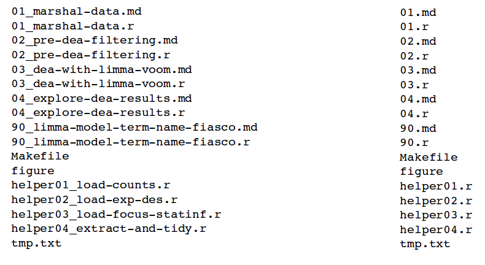

“naming things” by Jenny Bryan https://speakerdeck.com/jennybc/how-to-name-files

### BP: naming - plays well with default ordering

- put something numeric first
- use the ISO 8601 standard for dates (YYYY-MM-DD) everwhere, always without exception ever
- left pad numbers with zeroes as needed
  - 1_file_name.csv
  - 11_file_name.csv
  - 2_file_name.csv
  - ——————–
  - 01_file_name.csv
  - 02_file_name.csv
  - 11_file_name.csv

“naming things” by Jenny Bryan https://speakerdeck.com/jennybc/how-to-name-files

### BP: dates matter (a lot!)

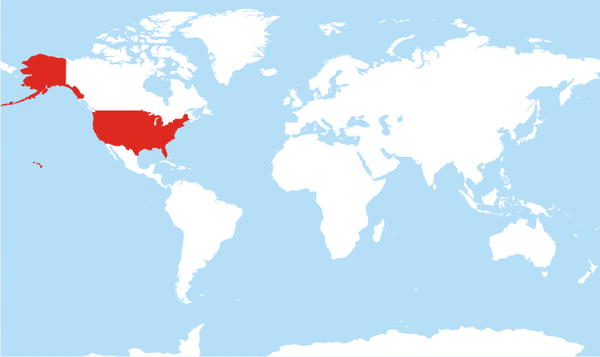

comprehensive map of all countries in the world that use MMDDYYYY format

use the ISO 8601 standard for dates (YYYY-MM-DD) everwhere, always without exception ever

“naming things” by Jenny Bryan https://speakerdeck.com/jennybc/how-to-name-files

### BP: employ sound project organization

your closest collaborator is you six months ago, but you do not reply to emails (Karl Broman paraphrasing Mark Holder)

- make the project understandable to others where others includes your future self
- segregate all the materials for a project in one directory
- separate raw from processed data; put code in a separate directory
- include README files

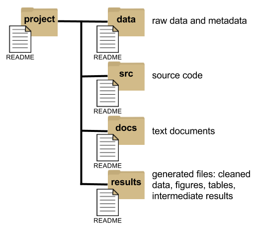

Steps toward reproducible research, Karl Broman, Biostatistics & Medical Informatics Univ. Wisconsin–Madison, kbroman.org, github.com/kbroman, @kwbroman, Slides: bit.ly/jsm2016

### BP: research compendium

…a standard and easily recognisable way for organising the digital materials of a project to enable others to inspect, reproduce, and extend the research

general principles:

- organize according to prevailing conventions (e.g., R package structure)
- maintain a clear separation of data, method, and output, while unambiguously expressing the relationship between the three
- specify the computational environment used for the original analysis
- organize such that another person can know what to expect from the plain meaning of the file and directory names

Marwick B, Boettiger C, Mullen L. (2017) Packaging data analytical work reproducibly using R (and friends) PeerJ Preprints 5:e3192v1 https://doi.org/10.7287/peerj.preprints.3192v1

### BP: keep the raw data raw

- save the raw data

Wilson G, Bryan J, Cranston K, Kitzes J, Nederbragt L, Teal TK (2017) Good enough practices in scientific computing. PLoS Comput Biol13(6): e1005510. https://doi.org/10.1371/journal.pcbi.1005510

### BP: thoughtful curation

- curate your data in a way that you would like to receive it

Wilson G, Bryan J, Cranston K, Kitzes J, Nederbragt L, Teal TK (2017) Good enough practices in scientific computing. PLoS Comput Biol13(6): e1005510. https://doi.org/10.1371/journal.pcbi.1005510

### BP: open file formats

- use open file formats (e.g., csv not xlsx)

Wilson G, Bryan J, Cranston K, Kitzes J, Nederbragt L, Teal TK (2017) Good enough practices in scientific computing. PLoS Comput Biol13(6): e1005510. https://doi.org/10.1371/journal.pcbi.1005510

### BP: analysis-friendly data

- create analysis-friendly data:
  - each column a variable
  - each row an observation

Wilson G, Bryan J, Cranston K, Kitzes J, Nederbragt L, Teal TK (2017) Good enough practices in scientific computing. PLoS Comput Biol13(6): e1005510. https://doi.org/10.1371/journal.pcbi.1005510

- each column a variable
- each row an observation

| Sepal.Length | Sepal.Width | Petal.Length | Petal.Width | Species |
| --- | --- | --- | --- | --- |
| 5.1 | 3.5 | 1.4 | 0.2 | setosa |
| 4.9 | 3.0 | 1.4 | 0.2 | setosa |
| 4.7 | 3.2 | 1.3 | 0.2 | setosa |
| 4.6 | 3.1 | 1.5 | 0.2 | setosa |
| 5.0 | 3.6 | 1.4 | 0.2 | setosa |
| 5.4 | 3.9 | 1.7 | 0.4 | setosa |

Wilson G, Bryan J, Cranston K, Kitzes J, Nederbragt L, Teal TK (2017) Good enough practices in scientific computing. PLoS Comput Biol13(6): e1005510. https://doi.org/10.1371/journal.pcbi.1005510

- each column a variable
- each row an observation

| Species | metric | value |
| --- | --- | --- |
| setosa | Sepal.Length | 5.1 |
| setosa | Sepal.Length | 4.9 |
| setosa | Sepal.Length | 4.7 |
| setosa | Sepal.Length | 4.6 |
| setosa | Sepal.Length | 5.0 |
| setosa | Sepal.Length | 5.4 |
| setosa | Sepal.Width | 3.5 |
| setosa | Sepal.Width | 3.0 |
| setosa | Sepal.Width | 3.2 |
| setosa | Sepal.Width | 3.1 |
| setosa | Sepal.Width | 3.6 |
| setosa | Sepal.Width | 3.9 |
| setosa | Petal.Length | 1.4 |
| setosa | Petal.Length | 1.4 |
| setosa | Petal.Length | 1.3 |

Wilson G, Bryan J, Cranston K, Kitzes J, Nederbragt L, Teal TK (2017) Good enough practices in scientific computing. PLoS Comput Biol13(6): e1005510. https://doi.org/10.1371/journal.pcbi.1005510

### BP: record everything

- record all the steps of the data process

### BP: everything in a script

The most basic principle for reproducible research is: do everything via code

- downloading data from the web,
- converting an Excel file to CSV,
- renaming columns or variables,
- omitting bad samples or data points
- …do all of these with scripts

You will be tempted to open up a data file and hand-edit. But if you get a revised version of that file, you will need to do it again, and it will be harder to figure out what it was that you did.

Some things are more cumbersome via code but you will save time in the long run.

Steps toward reproducible research, Karl Broman, Biostatistics & Medical Informatics Univ. Wisconsin–Madison, kbroman.org, github.com/kbroman, @kwbroman, Slides: bit.ly/jsm2016

### BP: learn a language. any language, just do it

[figure not shown]

[figure not shown]

### spreadsheets: the dark side

[figure not shown]

### spreadsheets: the 2nd best tool for everything

[figure not shown]

the beauty and the travesty of spreadsheets is that they allow you to do just about anything

- data in merged cells
- data in formatting
- small multiples
- data in formulas

use open file formats (e.g., CSV, not XLSX)

“spreadsheets” by Jenny Bryan https://speakerdeck.com/jennybc/spreadsheets

consider, we want to remove samples that we feel may have been contaminated…

**in a R script**

…some work…

# remove samples 4, 5, 6, that may

# have been compromised due to

# wading upstream during sampling

chemistry_data %>%

filter(!sample_id %in% c(4,5,6))

…more work…

**in a spreadsheet**

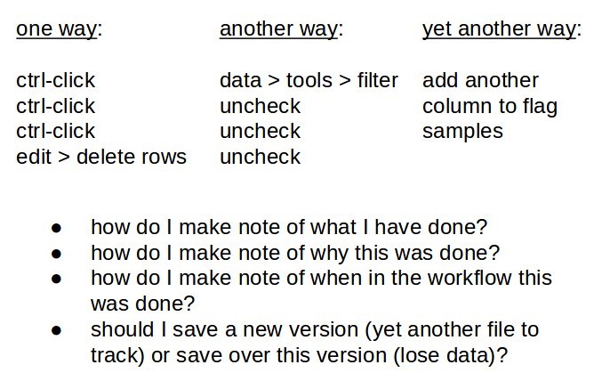

### literate programming

a common approach

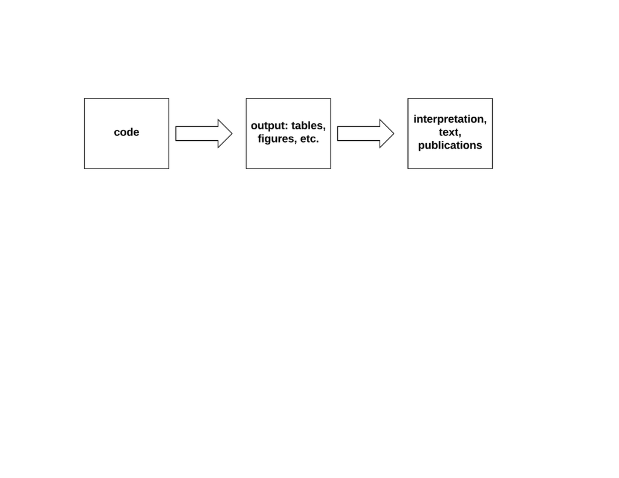

“The Plain Person’s Guide to Plain Text Social Science” version 2017-06-19 by Kieran Healy “https://kieranhealy.org/files/papers/plain-person-text.pdf”

### literate programming

- the problem is that the gaps are particularly prone to errors
- literate programming is essentially the integration of code and text

Knuth, D. E. (1992), Literate programming, CSLI Lecture Notes, Stanford, CA: Center for the Study of Language and Information (CSLI), 1992

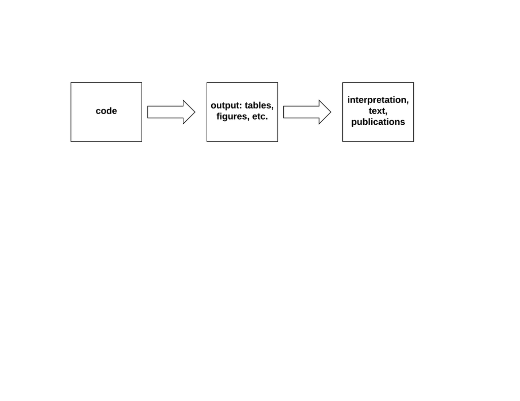

“The Plain Person’s Guide to Plain Text Social Science” version 2017-06-19 by Kieran Healy “https://kieranhealy.org/files/papers/plain-person-text.pdf”

### I am not saying it is easy

Kieran Healy on two revolutions in computing:

“On one side, the mobile, cloud-centered, touch-screen, phone-or-tablet model has brought powerful computing to more people than ever before.”

On the other side, tools for coding, data analysis, and writing are also revolutionary but mostly work by gluing together separate, specialized widgets that do much less to hide the operation system layer, and require knowledge of things like the file system.

“The Plain Person’s Guide to Plain Text Social Science” version 2017-06-19 by Kieran Healy “https://kieranhealy.org/files/papers/plain-person-text.pdf”

### OHI: nature ecology & evolution

[figure not shown]

Our path to better science in less time using open data science tools. Julia S. Stewart Lowndes, Benjamin D. Best, Courtney Scarborough, Jamie C. Afflerbach, Melanie R. Frazier, Casey C. O’Hara, Ning Jiang & Benjamin S. Halpern. Nature Ecology & Evolution 1, Article number: 0160 (2017) doi:10.1038/s41559-017-0160

### OHI: framework

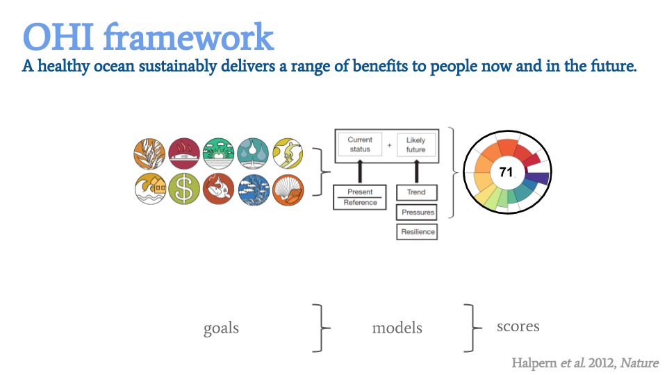

Our path to better science in less time using open data science tools. Julia S. Stewart Lowndes, Benjamin D. Best, Courtney Scarborough, Jamie C. Afflerbach, Melanie R. Frazier, Casey C. O’Hara, Ning Jiang & Benjamin S. Halpern. Nature Ecology & Evolution 1, Article number: 0160 (2017) doi:10.1038/s41559-017-0160

### OHI: evolution of a workflow

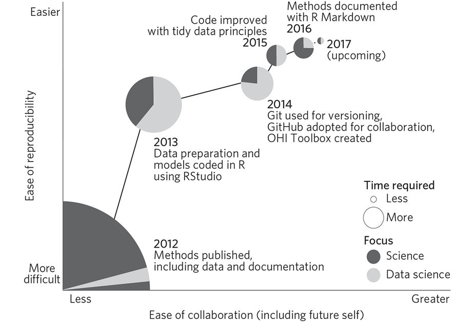

Our path to better science in less time using open data science tools. Julia S. Stewart Lowndes, Benjamin D. Best, Courtney Scarborough, Jamie C. Afflerbach, Melanie R. Frazier, Casey C. O’Hara, Ning Jiang & Benjamin S. Halpern. Nature Ecology & Evolution 1, Article number: 0160 (2017) doi:10.1038/s41559-017-0160

### BP: forethought

strive for reproducibility from the outset

### embrace openness

chaos in your code, file structure, and other components that make up your workflow may make you reluctant to share it with others - a sound workflow will make you more likely to share and to collaborate

[figure not shown]

Marwick B, Boettiger C, Mullen L. (2017) Packaging data analytical work reproducibly using R (and friends) PeerJ Preprints 5:e3192v1 https://doi.org/10.7287/peerj.preprints.3192v1

### embrace openness

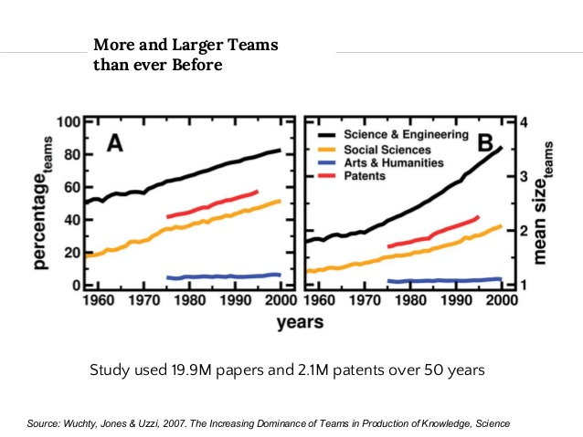

### embrace openness

[figure not shown]